# Chicago Bulls Player Selection 2019-2020

Sara Guevara

30/05/2020

# Overview

This report is designed to help selectors choose players for the Chicago Bulls NBA team for the 2019-20 season using a statistical approach. This approach uses statistics collected from the 2018-2019 season to analysis current teams and players to help create a statistical model that gives a value to each player to identify how successful they are at scoring points.

## Method overview

The method involves analysing and identifying the correlated variables that contribute to teams scoring points and therefore winning games. Once the variables are identified a *statistical model* was created to help predict which teams would win. Player specific statistics were then normalised by *minutes played*. The model was applied to the players statistical data and this helped to give each player one specific value that predicted their ability to score points per minute that they would play on the court. This was matched with the salary and the combination of these two factors helped chose the recommended top five starting players.

## Results

These five players were selected based on scoring the highest *expected points scoring* value in each of the five positions. Based on the team and player analysis the top five players that were chosen were:

- Johnathan Motley as power forward
- Malachi Richardson as Shooting guard
- James Nunnally as small forward
- Edmond Sumnar as point guard
- Ekpe Udoh as centre

The total salary of these starting 5 players comes well within the 2019-2020 budget at a total of $6,119,659.

The below report goes into more details about the analysis process of how the statistical model and variables were chosen and applied to the individual player data.

# Choosing the variables that result in winning NBA games.

## The question

There were two inital questions that were asked:

1. What variables contribute to players scoring points
2. Is it better to analyse these metrics based on winning games or by minutes played.

The aim for this report was to:

1. Choose variables that would contribute to helping NBA teams wins games and create a predictive statistical model to estimate points that would be scored
2. Compare the statistical model to the win percentage for the 2018-2019 season.
3. Apply the model to each players statistics and create a value for each player to predict their ability score points and help a team win.
4. Compare the player value metric to each athletes salary and use the combination to choose the starting five recommended players for the 2019-2020 NBA season for the Chicago Bulls.

## Method for chosing team metric.

The outcome variable was chosen to be points scored. The figure below (Figure 1) shows that to win a game you need to score at least 112 points. Therefore our aim is to find explanatory variables that have a positive relationship with scoring points.

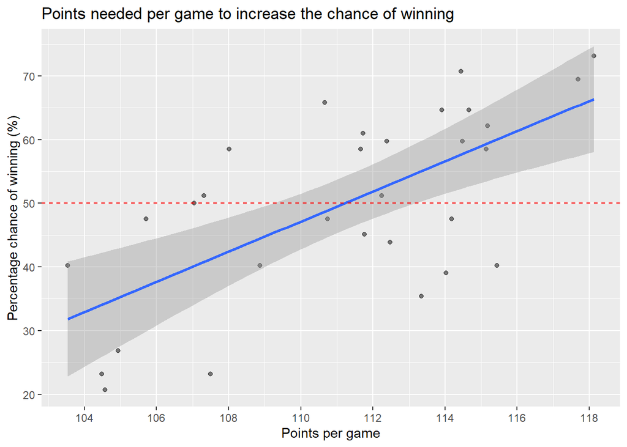

*Figure 1. Relationship between winning and scoring points in basketball*

The metrics that were considered as explanatory variables were *FG* = Field goals, *x3P* = 3-Point field goals, *x2P* = 2-point field goals, *FT* = Free throws, *ORB* = Offensive rebounds, *DRB* = Defensive rebounds, *TRB* = Total rebounds, *AST* = Assists, *STL* = Steals, *BLK* = Blocks, *TOV* Turnovers.

| term | estimate | std.error | statistic | p.value | conf.low | conf.high |
| --- | --- | --- | --- | --- | --- | --- |
| (Intercept) | 0.0565586 | 0.0275403 | 2.0536634 | 0.0540325 | -0.0010840 | 0.1142012 |
| AST_pmp | -0.1175880 | 0.1046216 | -1.1239360 | 0.2750405 | -0.3365636 | 0.1013876 |
| FG_pmp | -0.1752793 | 0.1313110 | -1.3348412 | 0.1977040 | -0.4501163 | 0.0995577 |
| x3P_pmp | 3.5303186 | 0.2193738 | 16.0927072 | 0.0000000 | 3.0711639 | 3.9894733 |
| x2P_pmp | 2.4419972 | 0.1899900 | 12.8532964 | 0.0000000 | 2.0443437 | 2.8396508 |
| FT_pmp | 0.7769774 | 0.0638447 | 12.1698096 | 0.0000000 | 0.6433490 | 0.9106058 |
| STL_pmp | -0.4136456 | 0.2054216 | -2.0136426 | 0.0584308 | -0.8435979 | 0.0163067 |
| BLK_pmp | 0.2511412 | 0.2494692 | 1.0067019 | 0.3267275 | -0.2710040 | 0.7732863 |
| TOV_pmp | -0.2155027 | 0.1314897 | -1.6389325 | 0.1176807 | -0.4907137 | 0.0597083 |
| DRB_pmp | -0.2395266 | 0.1162710 | -2.0600727 | 0.0533565 | -0.4828845 | 0.0038313 |
| ORB_pmp | -0.1217050 | 0.1842920 | -0.6603923 | 0.5169293 | -0.5074325 | 0.2640225 |

```
##
## Call:
## lm(formula = PTS_pmp ~ x3P_pmp + x2P_pmp + FT_pmp, data = df_team)
##
## Residuals:
##       Min        1Q    Median        3Q       Max
## -0.006769 -0.001711  0.000411  0.001931  0.004647
##
## Coefficients:
##             Estimate Std. Error t value Pr(>|t|)
## (Intercept) 0.004374   0.016331   0.268    0.791
## x3P_pmp     3.022946   0.121777  24.824  < 2e-16 ***
## x2P_pmp     2.008010   0.083753  23.975  < 2e-16 ***
## FT_pmp      0.698848   0.065562  10.659 5.52e-11 ***
## ---
## Signif. codes:  0 '***' 0.001 '**' 0.01 '*' 0.05 '.' 0.1 ' ' 1
##
## Residual standard error: 0.003141 on 26 degrees of freedom
## Multiple R-squared:  0.9691, Adjusted R-squared:  0.9655
## F-statistic: 271.5 on 3 and 26 DF,  p-value: < 2.2e-16
```

### Checking assumptions for the chosen model.

Once the model was chosen all the assumptions to meet multiple linear regression modeling were tested. To confirm that *per minutes played* was a prefered metric to normalise the variables compared to *per game* - both models were tested with the selected positively correlated variables. All the assumptions were met for the *per minute played* metric, however the *per game* metric residuals did not seem to be normally distributed and failed the multicollinearity assumption.

Therefore the chosen model was:

```r
fit_mp <- lm(PTS_pmp ~   x3P_pmp + x2P_pmp + FT_pmp, data = df_team)
```

## Model testing

Now that the model had been chosen, we tested it out compared to the predicted wins for the 2018-2019 season (Figure 2).

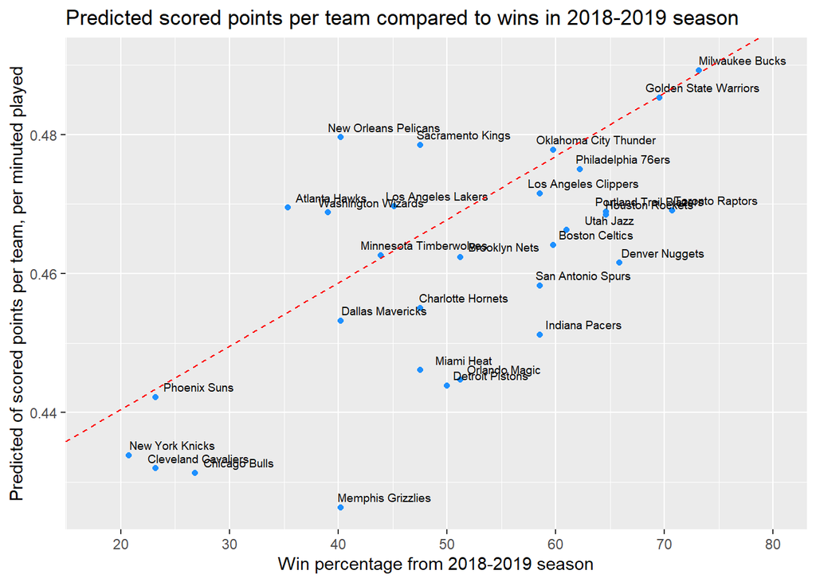

*Figure 2. Predicted wins based on predicted scored points per team*

Outliers were found during the model testing, however due to the minimal change in slope and intercept points for the model, these points were chosen to leave in the model.The risk of bias of the model was considered higher than the need to take the outlier points out.

## Applying team metric to players statistics

### Choosing player statistics

The explanatory variables in the player statistics were filtered out along with games played (G), games started (GS) and minutes played (MP). The chosen explanatory variables (3-pointer field goals, 2- pointer field goals, and free throws) along with the outcome variable (total points scored -PTS) were normalised relative to average minutes played by all potential players and games played.

The model was applied to each of the athletes to give them a predicted scoring value. This value was summarised in a table along with their most commonly played posiiton and their salary.

All the potential players in their positions were mapped out (see Figure 3).

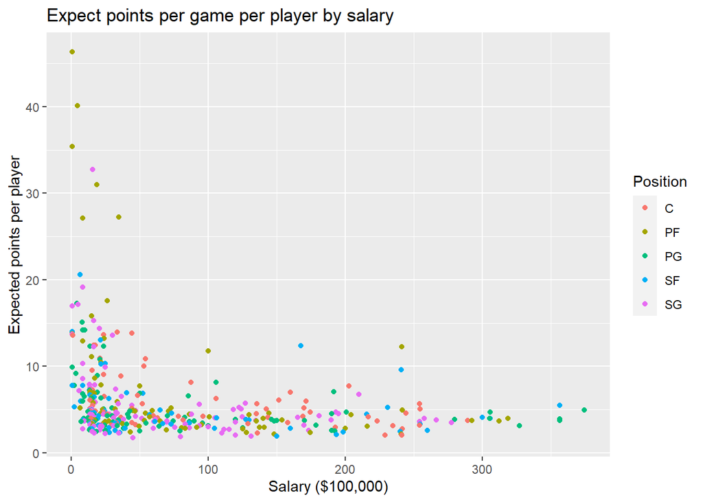

*Figure 3. Selecting players based on expected points per player*

Based on Figure 3 it can be seen that the players that were valued the highest were payed on the lower end of the salary scale.

## Recommended five starting players for the Chicago Bulls 2019-2020 season

Based on the summary table and the graph seen above, the following 5 players were chosen as the starting team for the2019-2020 season.

| player_name | Pos | salary | exp_PTS_ppl |
| --- | --- | --- | --- |
| Johnathan Motley | PF | 77250 | 0.1932043 |
| Malachi Richardson | SG | 1569360 | 0.1364240 |
| James Nunnally | SF | 663255 | 0.0856915 |
| Edmond Sumner | PG | 449794 | 0.0720607 |
| Ekpe Udoh | C | 3360000 | 0.0580263 |

*Table 3. Recommended starting five players based on predictive model.*

The total salary for these five players was found to be: $6,119,659. This is well within the 118,000,000 budget. There will be no issues with recuiting another seven to ten players that are within the budget. The recommendations for choosing the rest of the players will be based on using the above model and times it by each players salary to come up with one value figure for each player and use that as a method to chose the other players that are next in line for each player position.